# RSF for murres

Marie Auger-Méthé

2026-01-16

# Set up

## Packages

```r
library(here) # To simplify data sharing
library(tidyverse)
library(ggpubr) # To put plots side-by-side
library(sf) # to handle spatial object
library(amt) # to prep data for ssf (and fit simpler ssf)
library(glmmTMB)
library(terra)
library(tidyterra)
library(broom.mixed) # For coefficient plots
library(dotwhisker) # For coefficient plots
library(ggeffects) # For effects plot
library(kableExtra)
library(modelsummary)
options(modelsummary_factory_default = 'kableExtra') # New version has tinytable default option
options(modelsummary_factory_latex = 'kableExtra')
options(modelsummary_factory_html = 'kableExtra')
library(tinytable)
library(MuMIn) # for AICc
library(ggnewscale)
library(grafify) # For color-blind friendly palette
```

Colour for figures.

```r
# Same colour as figure 1.
col.oi <- col2rgb(palette.colors(palette = "Okabe-Ito"),
                  alpha = FALSE) # Colour-blind friendly palette
murre.col <- rgb(col.oi[1,8],
                 col.oi[2,8],
                 col.oi[3,8],
                 maxColorValue = 255)
water.col <- rgb(222, 235, 247, maxColorValue = 255)
land.col <- "floralwhite"
```

# Murre data

We chose to take 1 location per deployment, specifically the location that is farthest away from the colony, as it represents their destination and where they are likely foraging. For the three individuals for which we had 2 deployments, we randomly selected one deployment, leaving us with 54 independent foraging locations to analyse. Here are these selected locations.

```r
murres <- read.csv(file=file.path(here("Data/1_Murres/Movement"),
                                  "murres_rsf_clean_maxdist.csv"))
head(murres)
```

```
##                    dep_id metal_band dep_id_short       lon      lat
## 1   5AC_99699560_20230801   99699560     ID32_D01 -75.97883 73.03316
## 2   5AC_99699580_20230729   99699580     ID37_D02 -75.24560 73.07657
## 3   5AC_99699656_20230725   99699656     ID40_D03 -73.44464 73.50368
## 4  AA10_99699516_20230729   99699516     ID09_D05 -75.55524 73.19213
## 5  AA11_99699688_20230729   99699688     ID51_D07 -75.30984 72.77423
## 6 AA12_130600375_20230806  130600375     ID54_D08 -74.61424 72.99735
##          datetime_UTC datetime_release_UTC deployment_dur_min mass_gain
## 1 2023-08-01 21:39:59  2023-08-01 10:02:00                929       -45
## 2 2023-07-30 09:52:02  2023-07-30 00:37:00               1456       -19
## 3 2023-07-26 14:43:01  2023-07-25 23:10:00               1526       -24
## 4 2023-07-30 10:01:03  2023-07-30 00:52:00                854         0
## 5 2023-07-30 08:47:03  2023-07-30 00:44:00                744       -18
## 6 2023-08-06 18:10:01  2023-08-06 09:58:00               1407        18
##     rate_mass  dep_lon dep_lat  distNest    X_UTM   Y_UTM
## 1 -0.04843918 -76.0948 72.9425  10.80267 663375.6 8111031
## 2 -0.01304945 -76.0948 72.9425  31.48866 686705.7 8118000
## 3 -0.01572739 -76.0948 72.9425 105.91153 738882.0 8171795
## 4  0.00000000 -76.0948 72.9425  32.92190 675513.6 8129903
## 5 -0.02419355 -76.0948 72.9425  31.93594 687826.4 8084212
## 6  0.01279318 -76.0948 72.9425  48.80337 708064.6 8111286
```

We have a balanced number of deployment per years.

```r
# Make date time as date time object
murres$UTC_datetime <- ymd_hms(murres$datetime_UTC, tz="UTC")

murres %>% count(year(UTC_datetime))
```

```
##   year(UTC_datetime)  n
## 1               2022 27
## 2               2023 27
```

Formatting some of the columns.

```r
# Murre ID with deployment ID (so factor)
murres$dep_id_short <- as.factor(murres$dep_id_short)
# Date of release
murres$tagging_date_local <- with_tz(ymd_hms(murres$datetime_release_UTC, tz = "UTC"),
                                     tz = "America/Montreal")
```

Let’s create a data summary table.

Note for paper: need to add smaller font size in Latex: scriptsize after centering.

```r
murre.data.table <- murres %>%
  reframe("Individual" = metal_band,
          "Date of capture" = date(tagging_date_local),
          "Dist. from colony (km)" = round(distNest,2),
          "Duration (hr)" = round(deployment_dur_min/60,2),
          "Mass gained (g)" = mass_gain,
          "Rate of mass gain (g/hr)" = round(rate_mass, 3))
murre.data.table <- murre.data.table[order(murre.data.table$Individual),]

cat(kable(murre.data.table,
          format = "latex",
          caption = "Thick-billed murre data summary. For each individual (identified by their Canadian Wildlife Service bands), we present the date of capture, the duration of the deployment (in hours), the maximum distance from the colony for the farthest location of the foraging bout (in kilometres), the mass gained or lost during the deployment (in grams), and the rate of mass gain over the deployment (in grams per hour).",
          booktabs=TRUE, linesep = "", row.names = FALSE),
    file = "murre_data_summary.tex")
```

We will project all of our layers in the EPSG:32617 (WGS 84 / UTM zone 17N). Other layers are already projected to EPSG:32617.

```r
chosen.proj <- 32617
```

Get land and nest location. They are all already transformed in UTM.

```r
nests <- st_read(file.path(here("Data/1_Murres/Covariates/Nest_UTM"), "nests_UTM.shp"))
land <- st_read(file.path(here("Data/1_Murres/Covariates/Bylot_UTM"), "Bylot_UTM.shp"))
```

Create spatial object for murre data.

```r
murres.sf <- st_as_sf(murres, coords = c("X_UTM", "Y_UTM"), remove = FALSE)
st_crs(murres.sf) <- chosen.proj
```

# Function to prep data for RSF

Sample available locations. Check what is the farthest distance from nest/colony recorded.

```r
max(murres$distNest)
```

```
## [1] 105.9115
```

Set study area to be slightly larger: 125 km.

```r
radius.sa <- 125 #km
study.area <- st_buffer(nests[1,], radius.sa*1000)
study.area <- st_difference(study.area, land, sparse=FALSE)
```

Sample the available location.

```r
# Number of available per locations
n.avail <- 1000
# Sample more because we will remove those on land
set.seed(87876982)
rsf.avail <- random_points(study.area,
                           n = nrow(murres.sf)*n.avail*2) # Sample twice the amount needed
rsf.avail.sf <- st_as_sf(rsf.avail, coords=c("x_", "y_"))
st_crs(rsf.avail.sf) <- chosen.proj
```

Remove points on land.

```r
rsf.avail.sf$onLand <- rowSums(st_intersects(rsf.avail.sf, land, sparse = FALSE))
rsf.avail.sf <- subset(rsf.avail.sf, !onLand)
```

Keep only the amount needed.

```r
# Take only those that are needed (took more to remove land and nest)
rsf.avail.sf <- rsf.avail.sf[1:(n.avail*nrow(murres.sf)),]
nrow(rsf.avail.sf)/n.avail
```

```
## [1] 54
```

```r
nrow(murres.sf)
```

```
## [1] 54
```

Plot the study area with available points for supplementary material.

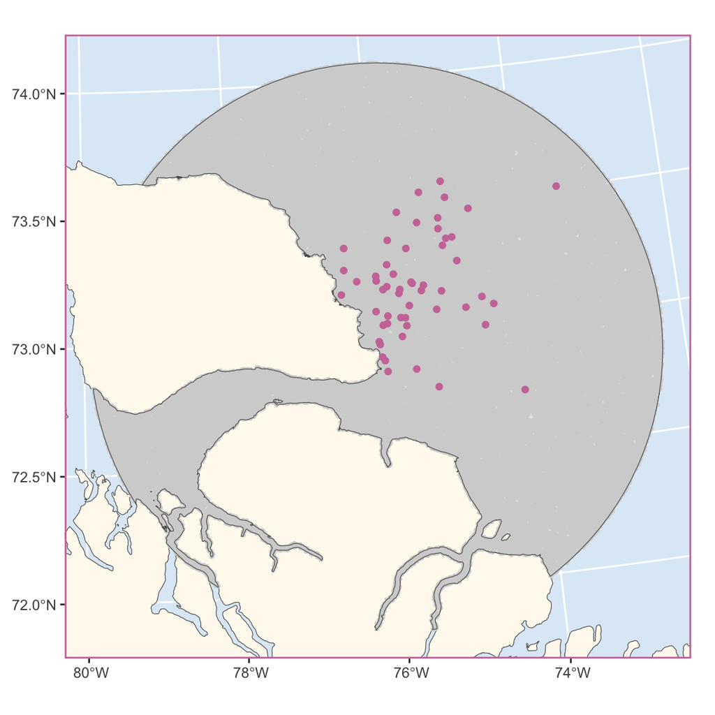

```r
study.area.box <- st_bbox(study.area)
mar.all <- c(0.5, 1, 0.5, 0.5) # margin
ggplot() +
  geom_sf(data = study.area) +
  geom_sf(data = land, fill= land.col) +
  geom_sf(data = rsf.avail.sf, col= "lightgrey", cex = 0.7) +
  geom_sf(data = study.area, fill = NA) +
  geom_sf(data = murres.sf, col=murre.col) +
  coord_sf(xlim = c(study.area.box[1], study.area.box[3]),
           ylim = c(study.area.box[2], study.area.box[4])) +
  theme(panel.background = element_rect(fill = water.col),
        panel.border = element_rect(colour = murre.col, fill=NA, linewidth = 1)) +
  theme(plot.margin = unit(mar.all, 'lines'),
        plot.background = element_rect(fill='transparent', color='transparent')) +
  scale_y_continuous(breaks = seq(70, 74, by = 0.5)) +
  scale_x_continuous(breaks = seq(-100, -70, by = 2)) +
  theme(axis.title.x=element_blank(),
        axis.title.y=element_blank())
```

Link availables to observed points.

```r
cols <- c("dep_id", "dep_id_short", "rate_mass", "mass_gain", "UTC_datetime")
murres.sf$case_ <- TRUE
murres <- st_drop_geometry(murres.sf)

for(i in seq_along(cols)){
    rsf.avail.sf[,cols[i]] <- rep(murres[,cols[i]], each = n.avail)
}
rsf.all.sf <- rbind(murres.sf[, c("case_",cols)],
                    rsf.avail.sf[, c("case_",cols)])
```

Calculate the distance from colony for all locations, including available points. Here we used straight line distance to keep the case study as simple as possible, but one could consider looking at distance over water to account for the propensity of murres to travel over water.

```r
rsf.all.sf$distCol <- as.numeric(st_distance(rsf.all.sf,
                                                   nests[1,]))/1000
```

```r
all.steps <- as.data.frame(rsf.all.sf)

# Get the actual individual ID (not just deployment ID)
all.steps$ID <- substr(all.steps$dep_id_short,1,4)
```

As numeric.

```r
all.steps$case <- as.numeric(all.steps$case_)
```

Weight for RSF. See Muff et al. (2020).

```r
all.steps$weight <- 1000^(1-all.steps$case)
```

## Fit models

```r
fit.rsf <- function(formula, data, start = list(theta = log(1e6)),
                    map = list(theta = factor(NA))){
    rsf <- glmmTMB(formula, family = binomial,
                 data = data, start = start, map = map, weights = weight)
  return(rsf)
}
```

AICc table function.

```r
AICcTable <- function(m, ...){
  namesObj <- names(tibble::lst(m, ...))
  namesObj[1] <- deparse(substitute(m))
  AICc.table <- AICc(m, ...)
  row.names(AICc.table) <- namesObj
  AICc.table <- AICc.table %>% mutate(deltaAICc = AICc - min(AICc, na.rm = TRUE))
  AICc.table[order(AICc.table$deltaAICc),]
}
```

Base info for tables of results.

```r
title <- "Parameter estimates from the two murre RSFs. The parameter estimates along with their standard errors are presented. A * indicates that the p-value comparing this parameter value to 0 is significant at the signicance level of 0.05. Note that as recomended by Muff et al. (2020), we have fixed the value of the standard deviation (SD) of the intercept to a large value (1e6). Note that while we estimate the intercept value, we do not report its value as it is ecologically irrelevant."

coef_map <- c("distCol" = "$\\beta_1: d_{n,j}$", # Distance to colony
              "distCol:rate_mass" = "$\\beta_2: m_n \\times d_{n,j}$") #"Distance to colony X Rate of mass gain"


estimates <- "{estimate}{stars}"
statistics <- "({std.error})"
```

We will look at two RSFs that model selection as a function of distance to colony: a baseline model that only includes distance to colony as a covariate, and a proxy-informed model that includes an interaction with the rate of mass gain.

Model 1 (baseline model): Rate of mass gain ignored

The model used to estimate the parameters of the baseline RSF is

$$\text{logit}(\pi_{n,j}) = \beta_{0,n} +
\beta_{1}d_{n,j}\qquad y_{n,j} \sim
\text{Bernoulli}(\pi_{n,j}),$$
where logit represents the logistic link function, $y_{n,j}$ is a variable that represent whether point $j$ of individual $n$ is a used ($y_{n,j} = 1$ for $j = 0$) or available point ($y_{n,j} = 0$ for $j = 1, ..., J$), $d_{n,j}$ is the distance to colony for point $j$ of individual $n$, and the intercept is modelled with a random effect that has a standard deviation fixed to a large value, here $\beta_{0,n} \sim \text{N}(\beta_0, 1000000^2)$.

```r
rsf.jd <- fit.rsf(formula = case ~ distCol +
                      (1 | dep_id),
                      data = all.steps)
summary(rsf.jd)
```

```
##  Family: binomial  ( logit )
## Formula:          case ~ distCol + (1 | dep_id)
## Data: data
## Weights: weight
##
##       AIC       BIC    logLik -2*log(L)  df.resid
##    2983.2    3001.0   -1489.6    2979.2     54052
##
## Random effects:
##
## Conditional model:
##  Groups Name        Variance Std.Dev.
##  dep_id (Intercept) 1e+12    1e+06
## Number of obs: 54054, groups:  dep_id, 54
##
## Conditional model:
##               Estimate Std. Error z value Pr(>|z|)
## (Intercept) -2.849e-09  1.217e+05   0.000        1
## distCol     -4.928e-02  5.479e-03  -8.995   <2e-16 ***
## ---
## Signif. codes:  0 '***' 0.001 '**' 0.01 '*' 0.05 '.' 0.1 ' ' 1
```

Model 2 (proxy-informed model): Rate of mass gain included

The model used to estimate the parameters of the proxy-informed RSF is:

$$\text{logit}(\pi_{n,j}) = \beta_{0,n} +
\beta_{1}d_{n,j} + \beta_{2}m_nd_{n,j} \qquad y_{n,j} \sim
\text{Bernoulli}(\pi_{n,j}),$$

which differ from model one only in one term where $\beta_2$ is the interaction between selection and $m_n$ the rate of mass gain during the foraging trip of individual $n$.

We only have one location per trip, so there is no need to account for pseudo-replication, and not enough data to estimates individual variation in RSF. Therefore, we have not included a random effect on $\beta_1$ in both models nor $\beta_2$ in model 2. In the simulation study (`1_rsf_simulations.Rmd`), we show that when there is only one used point per individual, we need a random effect only on the intercept to account for the nested data structure. This nested data structure is created because we need to associate available points to each individual to assign them a rate of mass gain value so that we can include rate of mass gain in the model.

```r
rsf.jd.fit <- fit.rsf(formula = case ~
                        distCol + distCol:rate_mass +
                      (1 | dep_id),
                      data = all.steps)
summary(rsf.jd.fit)
```

```
##  Family: binomial  ( logit )
## Formula:          case ~ distCol + distCol:rate_mass + (1 | dep_id)
## Data: data
## Weights: weight
##
##       AIC       BIC    logLik -2*log(L)  df.resid
##    2980.3    3007.0   -1487.2    2974.3     54051
##
## Random effects:
##
## Conditional model:
##  Groups Name        Variance Std.Dev.
##  dep_id (Intercept) 1e+12    1e+06
## Number of obs: 54054, groups:  dep_id, 54
##
## Conditional model:
##                     Estimate Std. Error z value Pr(>|z|)
## (Intercept)       -2.142e-09  1.144e+05   0.000   1.0000
## distCol           -4.691e-02  5.553e-03  -8.448   <2e-16 ***
## distCol:rate_mass  4.084e-01  1.905e-01   2.143   0.0321 *
## ---
## Signif. codes:  0 '***' 0.001 '**' 0.01 '*' 0.05 '.' 0.1 ' ' 1
```

```r
AICcTable(rsf.jd, rsf.jd.fit)
```

```
##            df     AICc deltaAICc
## rsf.jd.fit  3 2980.334  0.000000
## rsf.jd      2 2983.159  2.824515
```

```r
models <- list("Ignored" = rsf.jd,
               "In selection function" = rsf.jd.fit)

model.est <-  modelsummary(models,
                           estimate = estimates,
                           statistic = statistics,
             coef_map = coef_map,
             gof_map = NA,
             fmt = fmt_significant(3),
             stars = c("*"=0.05),
             title = title,
             escape = FALSE) %>%
  add_header_above(c("Par: Variables" = 1, "Rate of mass gain" = 2),
                   escape = FALSE)
```

```r
options(modelsummary_format_numeric_latex = "plain")
# To output for latex
table.latex <- modelsummary(models,
             estimate = estimates,
             statistic = statistics,
             coef_map = coef_map,
             gof_map = NA,
             fmt = fmt_significant(3),
             stars = c("*"=0.05),
             title = title,
             output = "murre_par_est.tex",
             escape = FALSE) %>%
  add_header_above(c("Par: Variables" = 1, "Rate of mass gain" = 2),
            escape = FALSE)
cat(table.latex, file="murre_par_est.tex")
```

Predict RSF for study area. First create a raster of study area.

```r
# Create raster with distance to colony
nrows <- ncols <- 500
m <- matrix(1:(nrows*ncols), nrow=nrows, ncol=ncols)
grid <- rast(m, extent=study.area.box, crs = crs(nests))
dist.nest <- distance(grid, nests)/1000
# Limit to study area.
dist.nest[dist.nest > radius.sa] <- NA
names(dist.nest) <- "distCol"
```

Predict RSF.

```r
rsf.map.nomass <- exp(summary(rsf.jd)$coef$cond["distCol",1] * dist.nest)
rsf.map.minmass <- exp(summary(rsf.jd.fit)$coef$cond["distCol",1] * dist.nest +
  summary(rsf.jd.fit)$coef$cond["distCol:rate_mass",1] * dist.nest * min(all.steps$rate_mass))
rsf.map.maxmass <- exp(summary(rsf.jd.fit)$coef$cond["distCol",1] * dist.nest +
  summary(rsf.jd.fit)$coef$cond["distCol:rate_mass",1] * dist.nest * max(all.steps$rate_mass))

all.preds <- rast(list(mass.ignored = rsf.map.nomass,
                       min.mass = rsf.map.minmass,
                       max.mass =rsf.map.maxmass))
```

Colour for min and max mass and RSF and formatting.

```r
# From: graf_palettes[["OrBl_div"]]

mass.min.col <- "#9E3D21" #"#d73027"
mass.max.col <- "#2B5B8A" #"#4575b4"
mass.0.col <- "#D8D4C9" #"#ffffbf"

rsf.min.col <- "#ffffcc"
rsf.mid.col <- "#41b6c4"
rsf.max.col <- "#0c2c84"

legend.text.size <- 0.8
```

Making independent plots. Create mapping function.

```r
val.range <- range(as.data.frame(all.preds))
rate.mass.range <- range(murres.sf$rate_mass)

mapping <- function(model.name, col.box = "black", plot.mar = c(1,1,0,1)){
  map <- ggplot() +
    geom_spatraster(data = all.preds[[model.name]]) +
    scale_fill_gradient2(low=rsf.min.col, mid=rsf.mid.col, high=rsf.max.col,
                      midpoint = mean(val.range), limit = val.range, na.value = NA) +
    geom_sf(data=land, fill=land.col, linewidth = 0.3) +
    geom_sf(data = study.area, fill = NA, linewidth = 0.3) +
    geom_sf(data = murres.sf, aes(col=rate_mass)) +
    scale_color_gradient2(low=mass.min.col, mid=mass.0.col, high= mass.max.col,
                      midpoint = 0, limit = rate.mass.range, na.value = NA) +
    coord_sf(xlim = c(study.area.box[1], study.area.box[3]),
           ylim = c(study.area.box[2], study.area.box[4]), expand = FALSE) +
    theme(panel.background = element_rect(fill = water.col),
          panel.border = element_rect(colour = col.box, fill=NA, linewidth = 0.5),
          legend.title = element_text(size = rel(0.5)),
          legend.text = element_text(size = rel(0.5)),
          legend.position = "top",
          legend.box = "horizontal",
          axis.text = element_text(size = rel(0.5)),
          axis.ticks = element_line(colour = 'black', linewidth = 0.1)) +
    guides(fill = guide_colorbar(title = "RSF", order = 1,
                                 theme = theme(legend.title =
                                                 element_text(size = rel(legend.text.size)))),
           col = guide_colorbar(title = "Rate of mass gain", order = 2,
                                 theme = theme(legend.title =
                                                 element_text(size = rel(legend.text.size))))) +
    theme(plot.margin = unit(plot.mar, 'lines')) +
  scale_y_continuous(breaks = seq(70, 74, by = 0.5)) +
  scale_x_continuous(breaks = seq(-100, -70, by = 2))
  return(map)
}
```

```r
map.mass.ignored <- mapping(model.name = "mass.ignored")
map.mass.min <- mapping(model.name = "min.mass", col.box = mass.min.col)
map.mass.max <- mapping(model.name = "max.mass", col.box = mass.max.col)
```

```r
legend.plot.map <- as_ggplot(get_legend(mapping(model.name = "mass.ignored")))
```

Show relationship with distance to colony.

```r
rel.dist <- data.frame(dist.col = seq(0, 125, by =1))
rel.dist$mass.ignored <- exp(summary(rsf.jd)$coef$cond["distCol",1] * rel.dist$dist.col)
rel.dist$mass.min <- exp(summary(rsf.jd.fit)$coef$cond["distCol",1] * rel.dist$dist.col +
  summary(rsf.jd.fit)$coef$cond["distCol:rate_mass",1] * rel.dist$dist.col * min(all.steps$rate_mass))
rel.dist$mass.0 <- exp(summary(rsf.jd.fit)$coef$cond["distCol",1] * rel.dist$dist.col)
rel.dist$mass.max <- exp(summary(rsf.jd.fit)$coef$cond["distCol",1] * rel.dist$dist.col +
  summary(rsf.jd.fit)$coef$cond["distCol:rate_mass",1] * rel.dist$dist.col * max(all.steps$rate_mass))
```

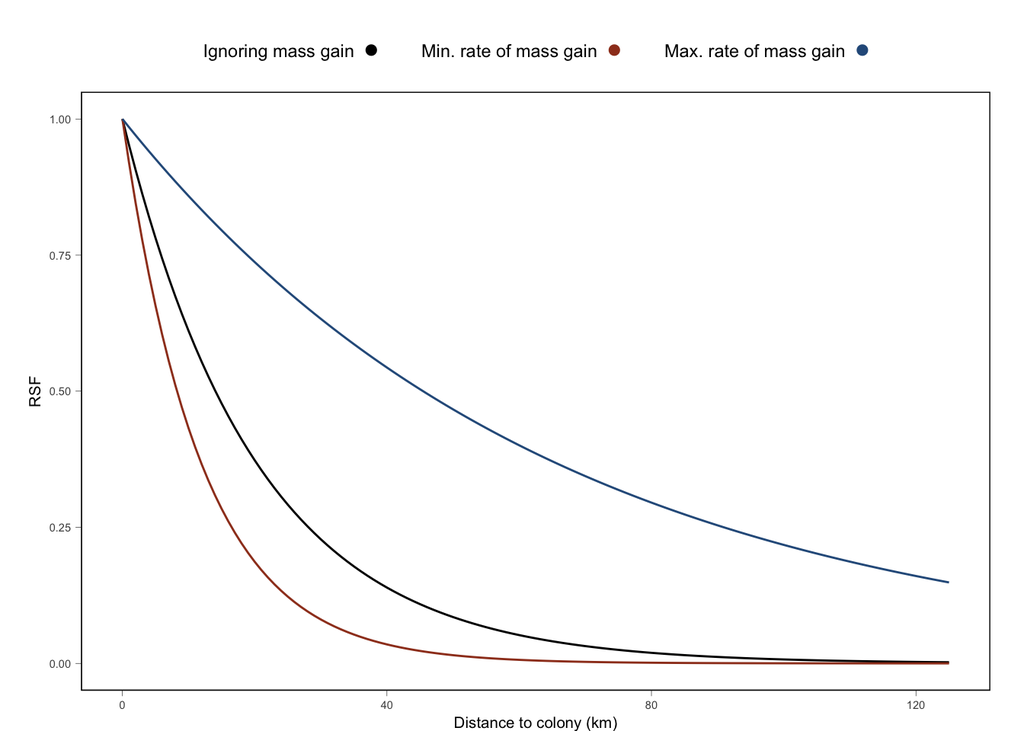

```r
rel.dist.plot <- ggplot() +
  geom_line(data = rel.dist, aes(x = dist.col, y = mass.ignored)) +
  geom_line(data = rel.dist, aes(x = dist.col, y = mass.min), color = mass.min.col) +
  geom_line(data = rel.dist, aes(x = dist.col, y = mass.max), color = mass.max.col) +
  theme(panel.border = element_rect(fill=NA, linewidth = 0.5)) +
  xlab("Distance to colony (km)") + ylab("RSF") +
  guides(Mass.ignored = guide_custom(grid::circleGrob(r = unit(0.1, "cm"),
                                                  gp = grid::gpar(fill = "black",
                                                                  col = NA)),
                                 title = "Ignoring mass gain", order = 1,
                                 theme = theme(legend.title =
                                                 element_text(
                                                   size = rel(legend.text.size)),
                                               legend.position = "top")),
           Mass.min = guide_custom(grid::circleGrob(r = unit(0.1, "cm"),
                                                  gp = grid::gpar(fill = mass.min.col,
                                                                  col = NA)),
                                 title = "Min. rate of mass gain", order = 2,
                                 theme = theme(legend.title =
                                                 element_text(
                                                   size = rel(legend.text.size)),
                                               legend.position = "top")),
           Mass.max = guide_custom(grid::circleGrob(r = unit(0.1, "cm"),
                                                  gp = grid::gpar(fill = mass.max.col,
                                                                  col = NA)),
                                 title = "Max. rate of mass gain", order = 4,
                                 theme = theme(legend.title =
                                                 element_text(
                                                   size = rel(legend.text.size)),
                                               legend.position = "top"))) +
    theme_classic() +
    theme(legend.position = "top",
          axis.title = element_text(size = rel(0.7)),
          axis.text = element_text(size = rel(0.5)),
          panel.border = element_rect(colour = "black", fill=NA, linewidth = 0.5),
          axis.line = element_line(colour = 'black', linewidth = 0.1),
          axis.ticks = element_line(colour = 'black', linewidth = 0.1),
          plot.margin = unit(c(1.05, 1.15, 0, 1), 'lines'))
rel.dist.plot
```

Grab legend.

```r
legend.plot.rel <- as_ggplot(get_legend(rel.dist.plot))
```

## Final figure with relationship to distance to colony

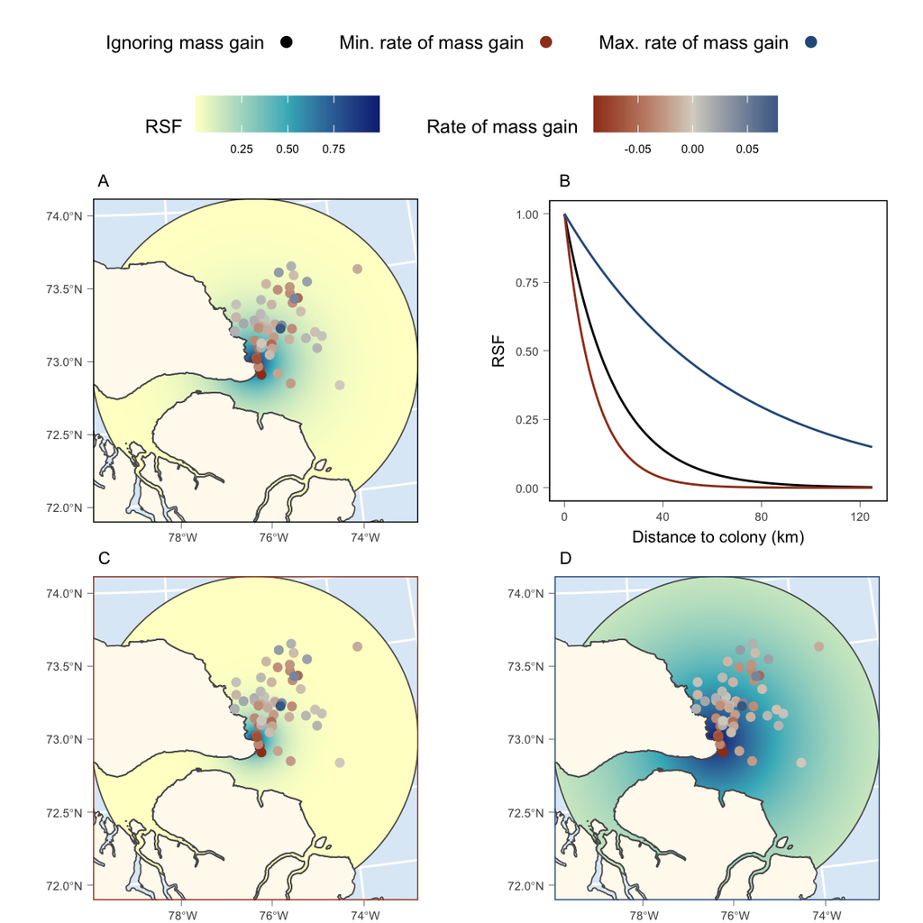

```r
ggarrange(ggarrange(legend.plot.rel, legend.plot.map,
                    nrow=2, widths = c(0.7, 0.5)),
          ggarrange(
          map.mass.ignored, rel.dist.plot,
          map.mass.min, map.mass.max, legend = "none",
          labels = c("A", "B", "C", "D"), label.x = rep(0.2,4), label.y = rep(1, 4),
              font.label = list(size = 8, face="plain"),
          nrow = 2, ncol = 2),
          nrow = 2, heights = c(0.2,0.9))
```

# Literature cited

Muff S., Signer J., & Fieberg J. (2020). Accounting for individual-specific variation in habitat-selection studies: Efficient estimation of mixed-effects models using Bayesian or frequentist computation. J Anim Ecol, 89, 80–92. https://doi.org/10.1111/1365-2656.13087